# Control de Versiones: Git

Residencia de Epidemiología

## Ciencia abierta, reproducibilidad y The Turing Way

[figure not shown]

- El control de versiones en un paso más que integra el paradigma de la investigación reproducible dentro de la open science.
- Existe una interesante iniciativa en la comunidad científica internacional denominado [The Turing Way](https://the-turing-way.netlify.app/welcome.html)

## Ciencia abierta, reproducibilidad y The Turing Way

- Este es un proyecto que sirve como guía de la ciencia de datos reproducible, ética y colaborativa.
- El proyecto es de código abierto, colaboración abierta y es impulsado por la misma comunidad.
- Su objetivo es proporcionar toda la información que los investigadores y científicos de datos en la academia, la industria y el sector público necesitan para garantizar que los proyectos en los que trabajan sean fáciles de reproducir y reutilizar.

## Archivos de código = Archivos de texto

[figure not shown]

## Control de versiones

- almacena ordenadamente un historial de cambios y quién los realizó.
- se pueden guardar metadatos del código escrito
- es invaluable para proyectos colaborativos donde diferentes personas trabajan paralelamente en el mismo código
- permite realizar un seguimiento de los cambios realizados y puede combinar automáticamente el trabajo de las personas

## Control de versiones

- el control de versiones es como un ‘deshacer’ sin límites
- los servicios de hospedaje de control de versiones, como GitHub, brindan una forma de comunicarse y colaborar de una manera estructurada, con solicitudes de incorporación de cambios, revisiones de código y problemas.

## Flujo de trabajo general

Un procedimiento típico para usar el control de versiones es el siguiente:

1. Cree archivos: estos pueden contener texto, código o ambos.
2. Trabaje en estos archivos cambiando, eliminando o agregando contenido nuevo.
3. Cree una instantánea del estado del archivo (también conocido como versión) en este momento. Puede agregarse un comentario como metadato.

## Ramificación

- Es un desarrollo no lineal del proyecto y se utiliza cuando desea agregar algo o probar algo antes de incorporarlo en el proyecto original.
- Una rama crea una copia local del repositorio principal donde puede trabajar y probar nuevos cambios
- Cualquier modificación que realice en la nueva rama no se reflejará en su proyecto principal, por lo que permanece seguro y sin errores.
- Cuando esté satisfecho con los nuevos cambios, puede introducirlos en el proyecto principal

## Ramificación

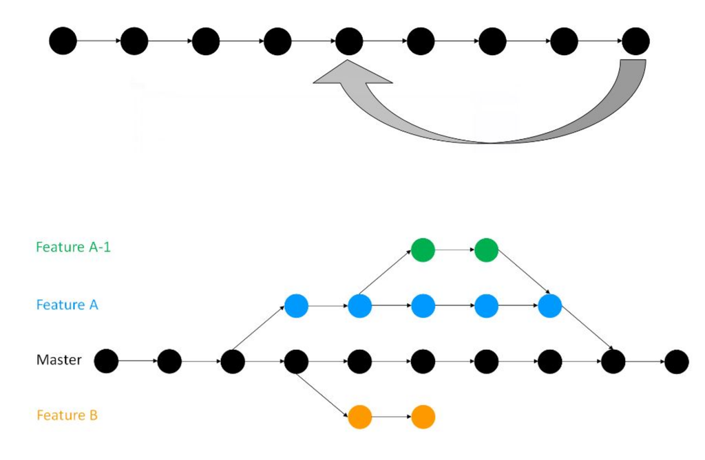

## En resumen: Ventajas de usar Git

- Usar Git junto a GitHub sirve como **copia de seguridad**
- Podemos recuperar **versiones anteriores** y conocer que cambios se hicieron (historial)
- Podemos **compartir y trabajar colaborativamente** sobre el mismo proyecto al mismo tiempo

## El software

- Git es un software de código abierto desarrollado originalmente por *Linus Torvalds* en 2005
- Se puede instalar en Windows, Linux y Mac.
- Para Windows se descarga del sitio [Git for Windows](https://gitforwindows.org/)
- Se integra con sitios como [GitHub](http://github.com/), [GitLab](http://gitlab.com/), [BitBucket](http://bitbucket.org/), etc.
- Se integra con IDE’s y editores como *RStudio*, Positron y VScode.

## Paquete usethis

El paquete usethis facilita la integración con Git, GitHub y herramientas de desarrollo de software.

También permite automatizar tareas de configuración y organización de proyectos de R, evitando tener que crear manualmente archivos, directorios y configuraciones.

Se instala con:

```r
install.packages("usethis")
```

Se activa con:

```r
library(usethis)
```

## Configuración inicial

- Abrimos RStudio y verificamos la versión desde la Terminal ejecutando:

```r
git --version
```

- Instalamos el paquete **usethis** y ejecutamos desde la consola:

```r
usethis::edit_git_config()
```

- Editar el archivo “.gitconfig” escibiendo:

```r
[user]
  name = nombre
  email = usuario@dominio.com
```

- Utilizar el mail que vamos a utilizar para crear la cuenta en GitHub

## Inicializar un repositorio

- Los repositorios Git se vinculan con los proyectos de RStudio, que a su vez se incluyen en carpetas (directorios).
- Se puede agregar un repositorio a un proyecto de RStudio existente o crear un proyecto con formato de repositorio Git.
- Para agregar un repositorio Git a un proyecto se ejecuta en consola:

```r
usethis::use_git()
# Elegir siempre la opción positiva (si, absolutamente, etc)
```

## Pestaña Git

- Si todo salió bien aparecerá una nueva pestaña en el panel donde se ubica el entorno (Environment)
- También se puede acceder desde los iconos del menú superior.
- Pulsando sobre el icono del reloj podemos visualizar el historial de cambios del repositorio.
- Vamos a probar el funcionamiento de la siguiente forma:

## Commit e historial

- Generamos un script nuevo llamado *prueba.R* y lo guardamos.
- Vamos a la pestaña Git de RStudio y pulsamos sobre el botón **commit**.
- En el panel del **commit** añadimos un texto que lo defina.
- Hacemos algunos cambios en el script *prueba.R* y en cada uno de ellos volvemos a pulsar **commit**.
- Luego revisamos la historia de los cambios que se han producido en el historial (pulsar el icono del *reloj*).
- Observamos los nuevos cambios resaltados en color verde, frente a los valores antiguos que aparecerán en color rojo.

## Otras funciones interesantes de usethis

`create_project()` — crear un proyecto de análisis

Crea un proyecto de R organizado en un directorio propio, con su archivo .Rproj cuando corresponde.

```r
usethis::create_project(
  "vigilancia_infecciones"
)
```

`use_github()` — conectar el proyecto con GitHub

Crea un repositorio remoto en GitHub y conecta el repositorio local, realizando una primera publicación.